# Red Wine Quality Exploration by Fern Liu

# 双变量绘图选择

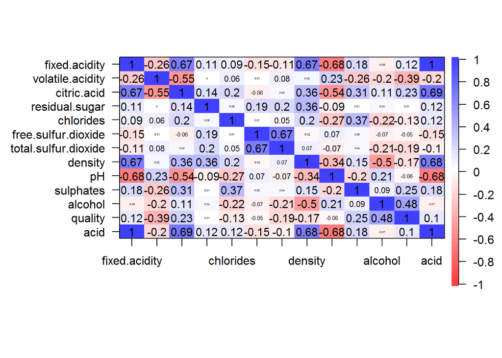

```
## Call:corCi(x = x, keys = keys, n.iter = n.iter, p = p, overlap = overlap,
##     poly = poly, method = method, plot = plot, minlength = minlength)
##
##  Coefficients and bootstrapped confidence intervals
##                      fxd.c vltl. ctrc. rsdl. chlrd fr.s. ttl.. dnsty pH
## fixed.acidity         1.00
## volatile.acidity     -0.26  1.00
## citric.acid           0.67 -0.55  1.00
## residual.sugar        0.11  0.00  0.14  1.00
## chlorides             0.09  0.06  0.20  0.06  1.00
## free.sulfur.dioxide  -0.15 -0.01 -0.06  0.19  0.01  1.00
## total.sulfur.dioxide -0.11  0.08  0.04  0.20  0.05  0.67  1.00
## density               0.67  0.02  0.36  0.36  0.20 -0.02  0.07  1.00
## pH                   -0.68  0.23 -0.54 -0.09 -0.27  0.07 -0.07 -0.34  1.00
## sulphates             0.18 -0.26  0.31  0.01  0.37  0.05  0.04  0.15 -0.20
## alcohol              -0.06 -0.20  0.11  0.04 -0.22 -0.07 -0.21 -0.50  0.21
## quality               0.12 -0.39  0.23  0.01 -0.13 -0.05 -0.19 -0.17 -0.06
## acid                  1.00 -0.20  0.69  0.12  0.12 -0.15 -0.10  0.68 -0.68
##                      slpht
## fixed.acidity
## volatile.acidity
## citric.acid
## residual.sugar
## chlorides
## free.sulfur.dioxide
## total.sulfur.dioxide
## density
## pH
## sulphates             1.00
## alcohol               0.09
## quality               0.25
## acid                  0.18
##         alchl qulty acid
## alcohol  1.00
## quality  0.48  1.00
## acid    -0.07  0.10  1.00
##
##  scale correlations and bootstrapped confidence intervals
##             lower.emp lower.norm estimate upper.norm upper.emp    p
## fxd.c-vltl.     -0.30      -0.30    -0.26      -0.21     -0.21 0.00
```

[output cut: 62 more lines]

```
## dnsty-pH        -0.39      -0.39    -0.34      -0.29     -0.30 0.00
## dnsty-slpht      0.11       0.11     0.15       0.19      0.20 0.00
## dnsty-alchl     -0.55      -0.54    -0.50      -0.44     -0.44 0.00
## dnsty-qulty     -0.22      -0.22    -0.17      -0.12     -0.12 0.00
## dnsty-acid       0.65       0.64     0.68       0.71      0.70 0.00
## pH-slpht        -0.25      -0.26    -0.20      -0.14     -0.14 0.00
## pH-alchl         0.14       0.14     0.21       0.26      0.25 0.00
## pH-qulty        -0.11      -0.11    -0.06      -0.01     -0.01 0.02
## pH-acid         -0.71      -0.71    -0.68      -0.66     -0.66 0.00
## slpht-alchl      0.05       0.04     0.09       0.15      0.15 0.00
## slpht-qulty      0.19       0.19     0.25       0.31      0.30 0.00
## slpht-acid       0.14       0.14     0.18       0.23      0.22 0.00
## alchl-qulty      0.43       0.43     0.48       0.52      0.51 0.00
## alchl-acid      -0.12      -0.13    -0.07       0.00      0.00 0.05
## qulty-acid       0.06       0.05     0.10       0.15      0.15 0.00
```

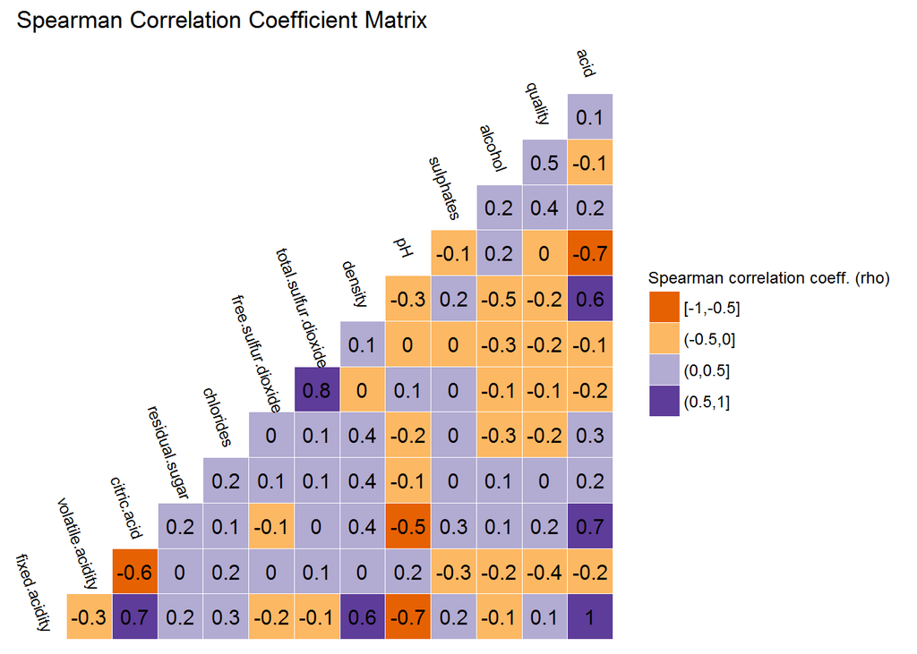

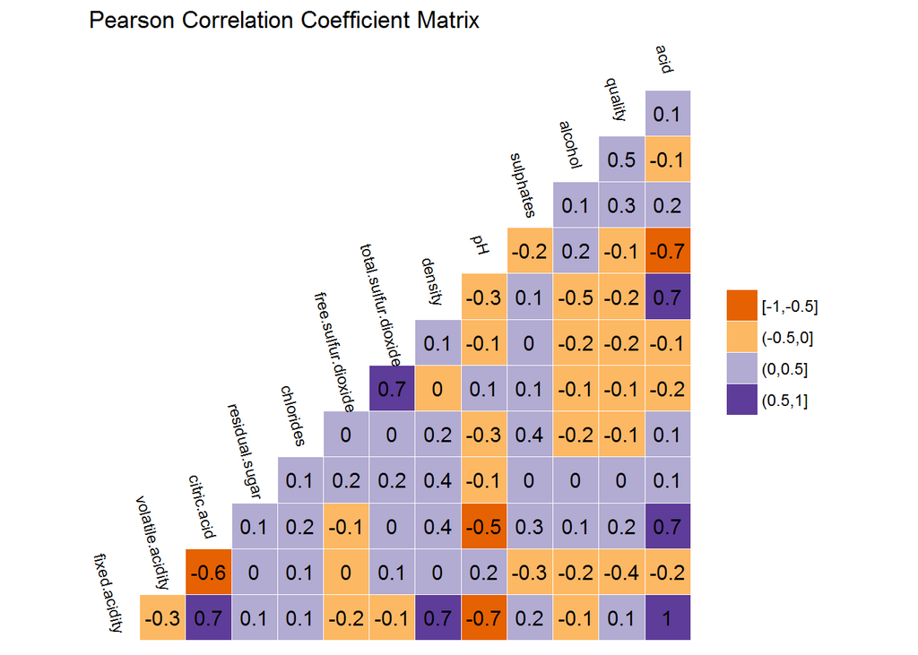

```
##
##  Pearson's product-moment correlation
##
## data:  red_wine_quality$quality and red_wine_quality$fixed.acidity
## t = 4.996, df = 1597, p-value = 6.496e-07
## alternative hypothesis: true correlation is not equal to 0
## 95 percent confidence interval:
##  0.07548957 0.17202667
## sample estimates:
##       cor
## 0.1240516
```

```
##    Min. 1st Qu.  Median    Mean 3rd Qu.    Max.
##    4.60    7.10    7.90    8.32    9.20   15.90
```

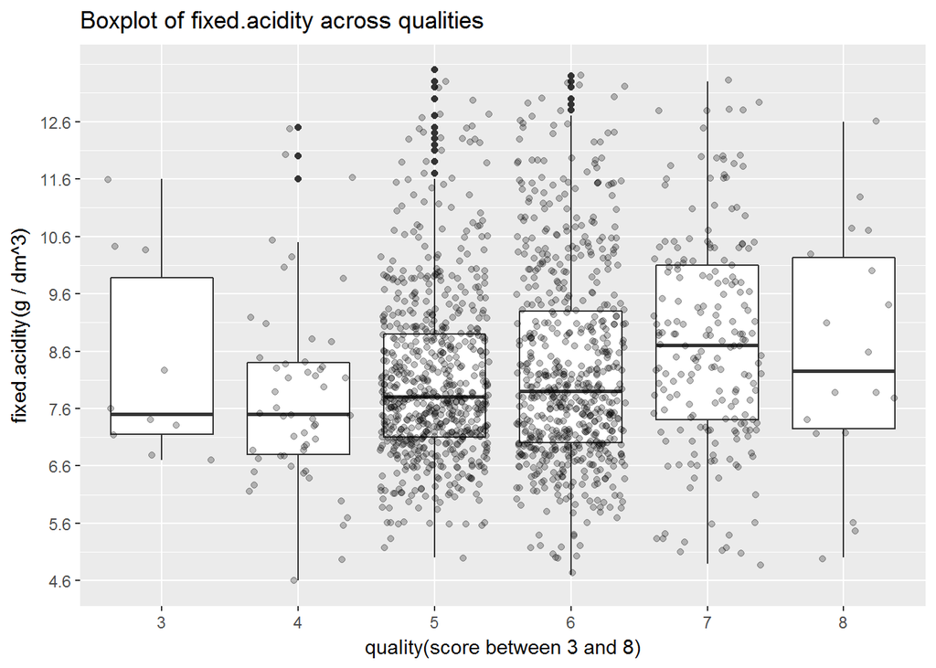

```
##    Min. 1st Qu.  Median    Mean 3rd Qu.    Max.
##  0.1200  0.3900  0.5200  0.5278  0.6400  1.5800
```

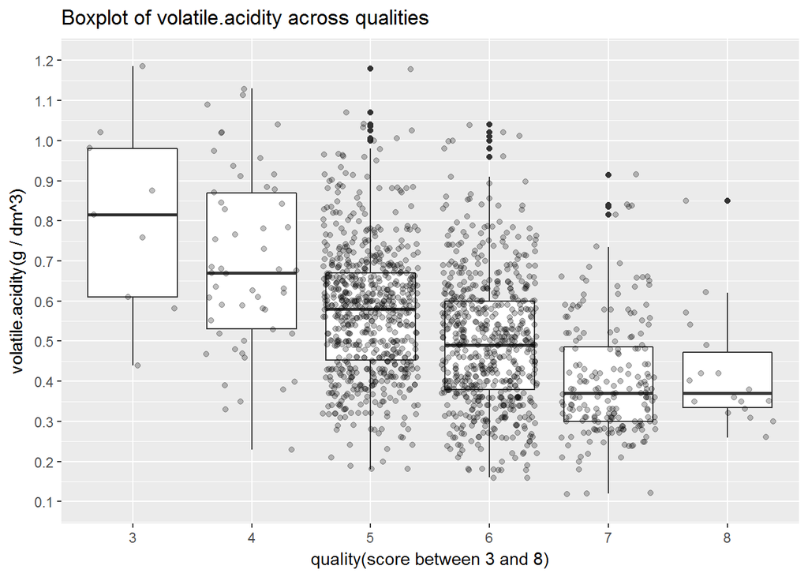

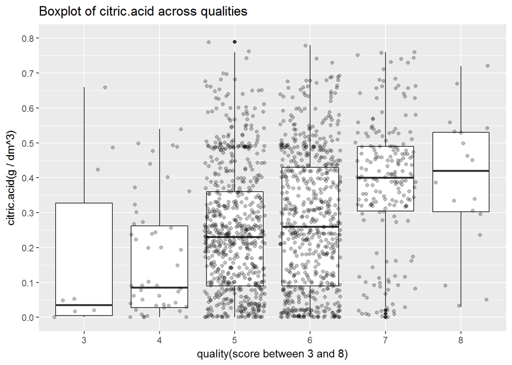

```
##
##  Pearson's product-moment correlation
##
## data:  red_wine_quality$fixed.acidity and red_wine_quality$citric.acid
## t = 36.234, df = 1597, p-value < 2.2e-16
## alternative hypothesis: true correlation is not equal to 0
## 95 percent confidence interval:
##  0.6438839 0.6977493
## sample estimates:
##       cor
## 0.6717034
```

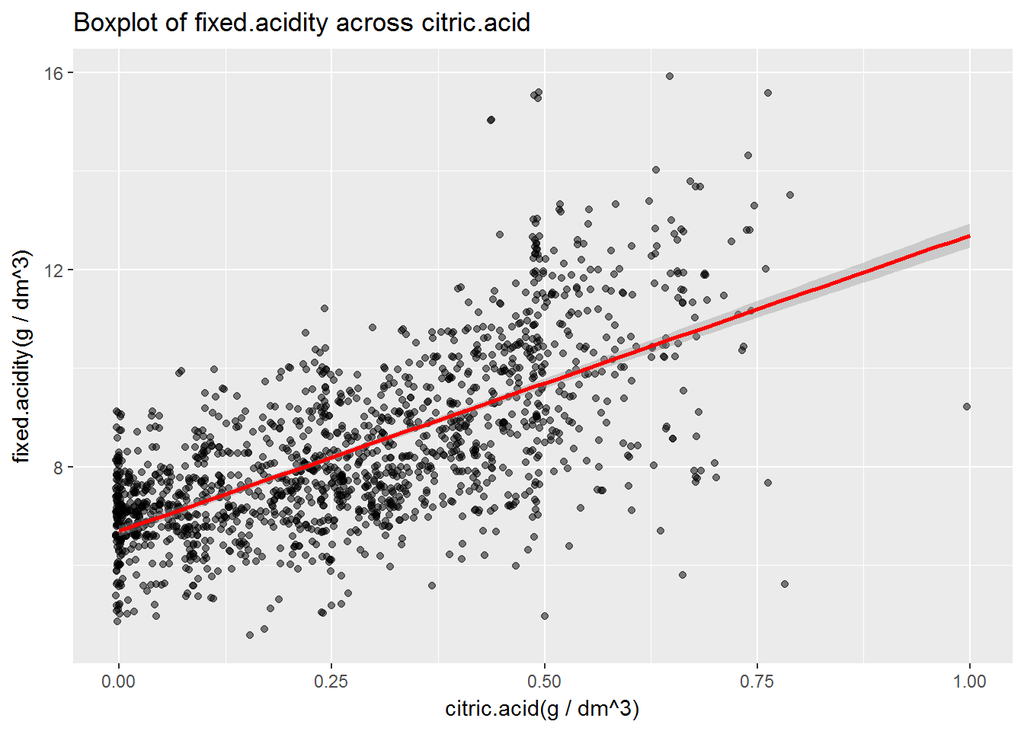

红酒固定酸度和红酒品质没有明显相关关系。红酒固定酸度和柠檬酸有较明显的正相关关系。 在柠檬酸含量小于0.5g每升时，柠檬酸含量的增加对红酒品质明显有促进作用。 volatile acidity挥发性酸和红酒品质呈现弱负相关关系。 上面分析了红酒含有的三种酸性物质对红酒品质的影响，下面看含硫物质对红酒品质有何作用。

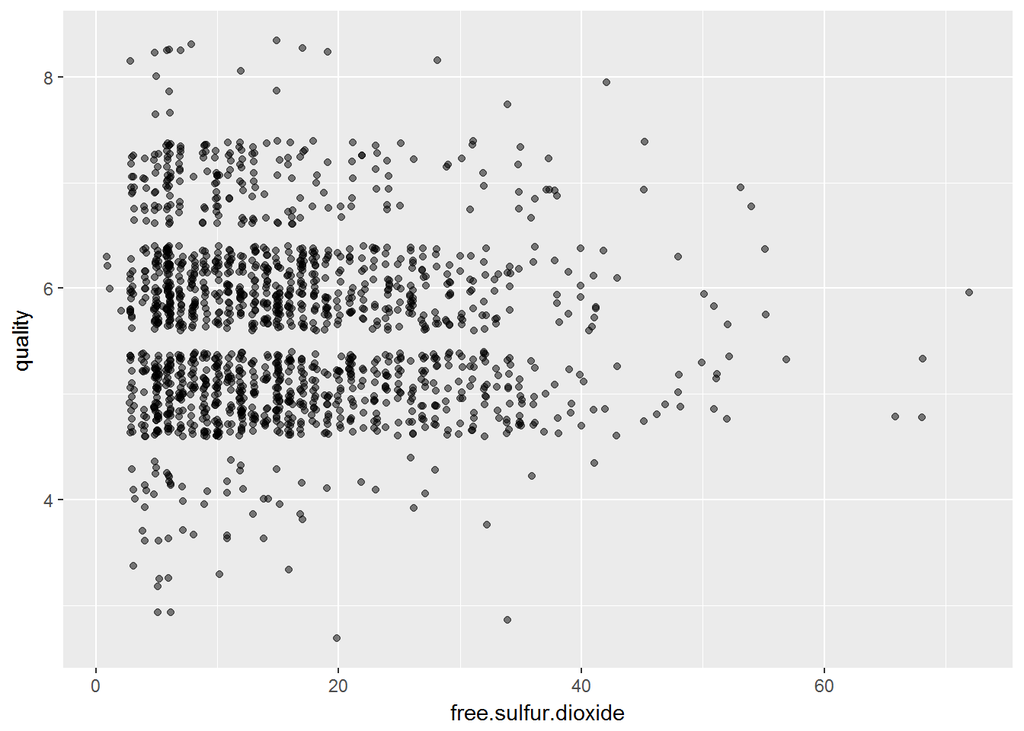

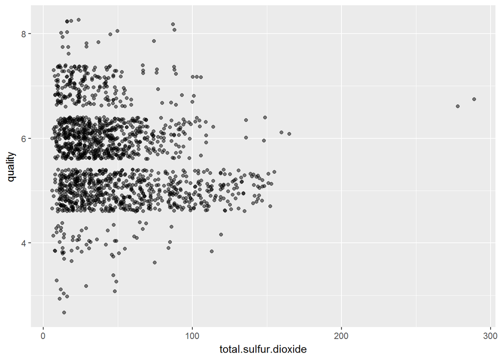

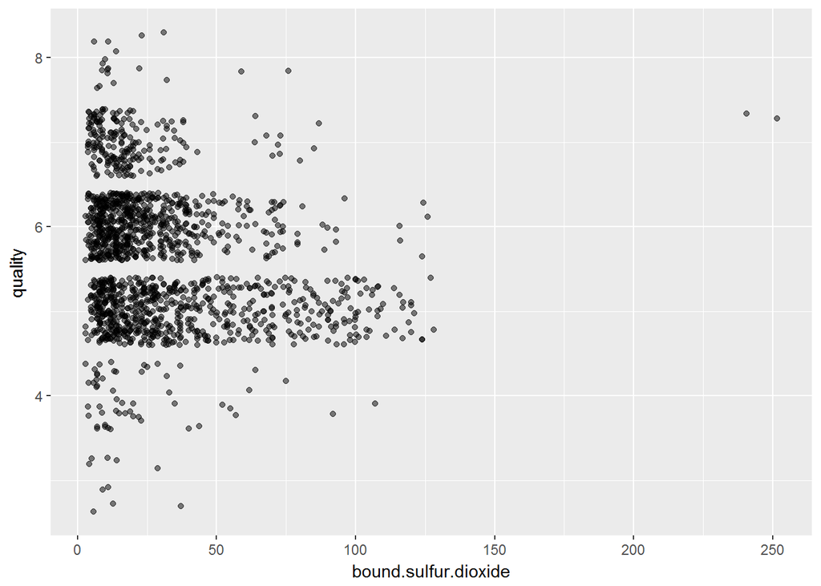

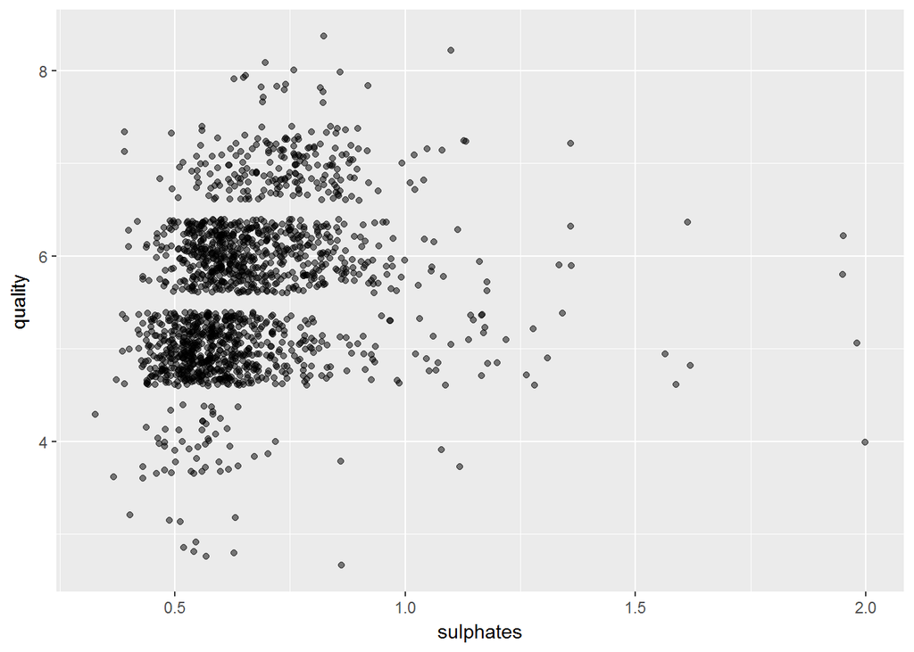

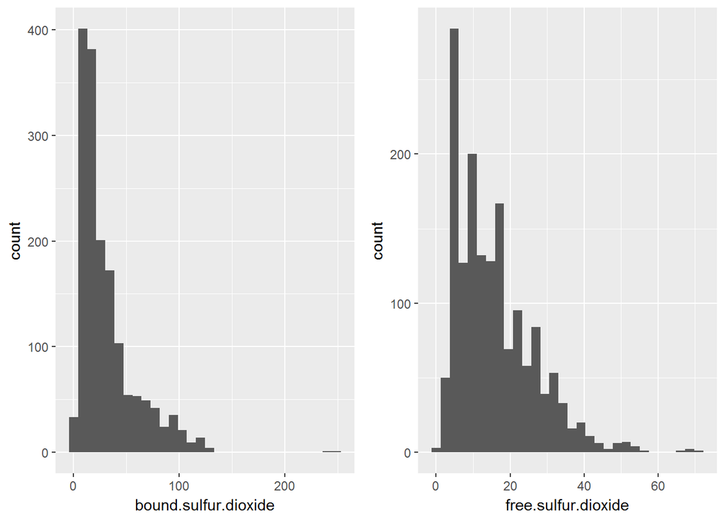

[figure not shown]

```
##
##  Pearson's product-moment correlation
##
## data:  red_wine_quality$sulphates and red_wine_quality$quality
## t = 10.38, df = 1597, p-value < 2.2e-16
## alternative hypothesis: true correlation is not equal to 0
## 95 percent confidence interval:
##  0.2049011 0.2967610
## sample estimates:
##       cor
## 0.2513971
```

红酒中含有的稳定二氧化硫比游离二氧化硫多， 而且稳定二氧化硫和红酒品质有弱负相关关系。硫酸盐含量和红酒品质呈现弱相关。 下面查看红酒密度和影响红酒密度的残留和酒精含量，分别对红酒品质有和影响。

```
##    Min. 1st Qu.  Median    Mean 3rd Qu.    Max.
##   0.900   1.900   2.200   2.539   2.600  15.500
```

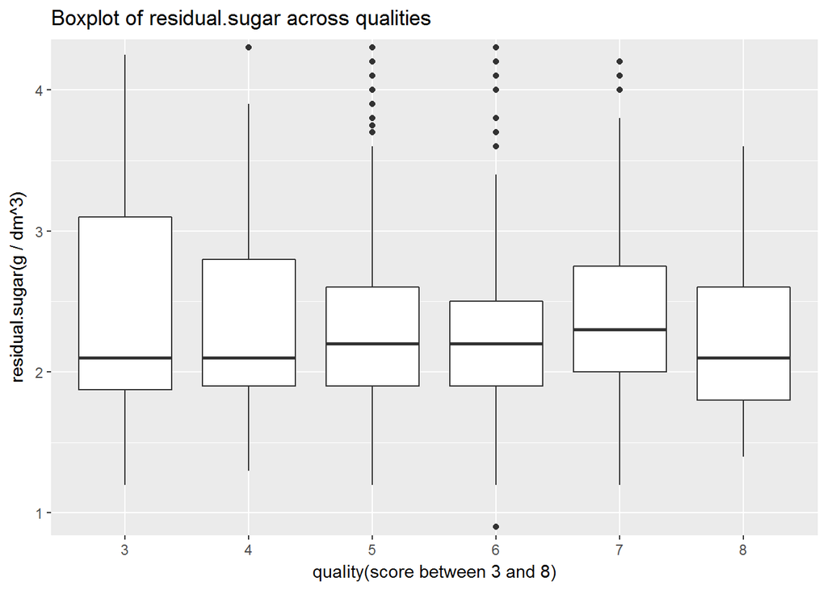

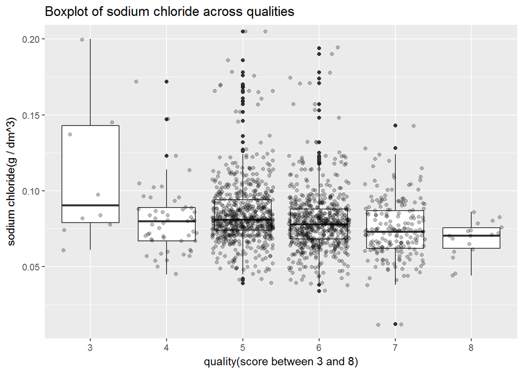

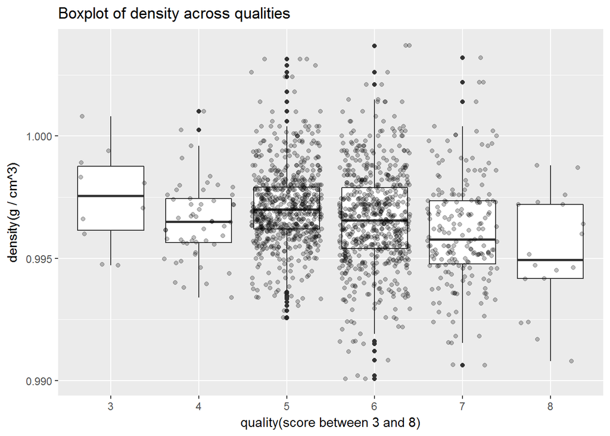

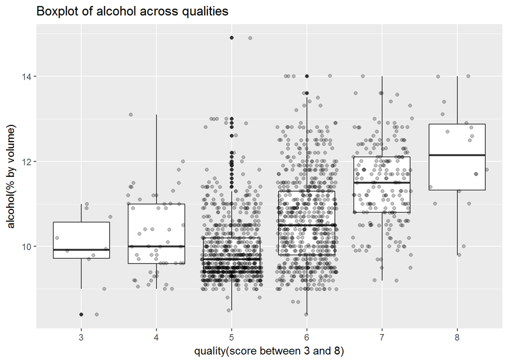

随着红酒品质级别的升高，平均残糖含量没有明显的变化，但是氯化物含量有稍微下降的趋势。酒精含量和红酒品质呈现中等正相关关系。对红酒品质级别分组，计算酒精含量的平均值，进一步查看酒精平均含量和红酒品质的关系。

```
## # A tibble: 6 x 3
##   quality alcohol_mean     n
##     <int>        <dbl> <int>
## 1       3         9.96    10
## 2       4        10.3     53
## 3       5         9.90   681
## 4       6        10.6    638
## 5       7        11.5    199
## 6       8        12.1     18
```

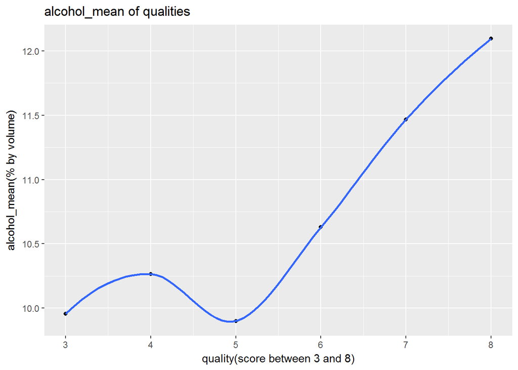

# 双变量分析

### 探讨你在这部分探究中观察到的一些关系。这些感兴趣的特性与数据集内其他特性有什么区别？

红酒酸度和红酒固定酸度有强相关关系。挥发性酸对红酒品质有负面影响， 而适量柠檬酸对红酒品质有正面作用。硫酸盐含量对红酒品质有弱正相关关系。

### 你是否观察到主要特性与其他特性之间的有趣关系？

固定酸度和挥发性酸度没有明显关联，但是固定酸度和柠檬酸却呈现正相关关系。 红酒酸度主要由固定酸度决定。红酒中含有的稳定二氧化硫比游离二氧化硫多。

### 你发现最强的关系是什么？

当红酒品质为中级偏上时，红酒品质越高，含有的酒精量越多。